# R markdown - How To Import An Excel File

Faith Kabanda

2022-07-25

## Notes

- *Echo = FALSE* allows you to hide the code.
- fig.show = “hide”: Hides plots. (leave two trailing spaces/lines to start new line in text)
- toc: true creates a table of contents. Remember to leave a space between “:” and “true” and remove “default” under *html/word* in **output**
- You can specify the toc_float option to float the table of contents to the left of the main document content. The floating table of contents will always be visible even when the document is scrolled

## R Markdown - Import Excel file

```r
library(readxl)
covid_data<- read_excel("C:/Users/Faith Kabanda/OneDrive/Desktop/My Research Work/Vaccines VS Data/covid who data.xlsx",
    sheet = "Jan 2021", range = "A1:E32")
summary(covid_data$New_cases)
```

```
##    Min. 1st Qu.  Median    Mean 3rd Qu.    Max.
##     0.0   334.0   639.0   633.7   829.5  1365.0
```

## Bloxplts

### Short Notes

- factor(0)
- stat_boxplot creates whiskers

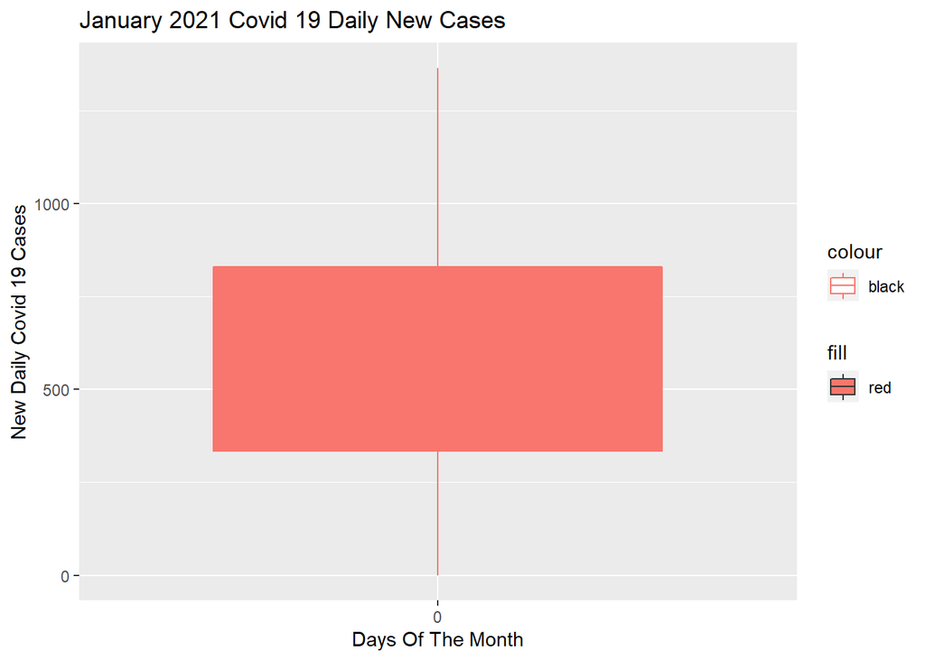

```r
library(ggplot2)
new_cases_boxplot<- ggplot(covid_data, aes(x = factor(0), y = New_cases, fill = "red", color = "black")) +stat_boxplot() + geom_boxplot() + xlab("Days Of The Month") + ylab("New Daily Covid 19 Cases") + ggtitle("January 2021 Covid 19 Daily New Cases")
new_cases_boxplot
```

## Scatter Plot

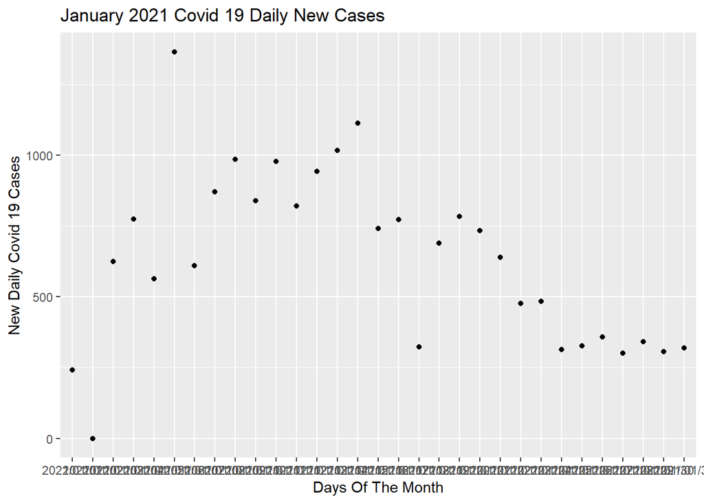

```r
library(ggplot2)
new_cases_scatterplot<- ggplot(covid_data, aes(x = Date_reported, y = New_cases)) + geom_point()+ xlab("Days Of The Month") + ylab("New Daily Covid 19 Cases") + ggtitle("January 2021 Covid 19 Daily New Cases")
new_cases_scatterplot
```

## Histogram

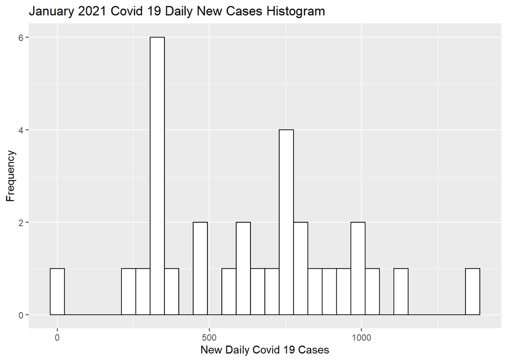

```r
library(ggplot2)
new_cases_histogram<- ggplot(covid_data, aes(x = New_cases)) + geom_histogram(color = "black", fill = "white") + xlab("New Daily Covid 19 Cases") + ylab("Frequency") + ggtitle("January 2021 Covid 19 Daily New Cases Histogram")
new_cases_histogram
```